### Context

Ever since the inception of the Euro, debates have raged about its design and membership. This debate has become even more prominent since the start of the financial crisis, which led to a debt crisis in the Eurozone. Critics of the Euro argue that a single monetary policy is unsuitable for its members who still have divergent macroeconomic conditions and cycles, insuficient labour mobility and fiscal integration. While some critics argue in favour of breaking up the monetary union, other have argued in favour of completing it with a stronger fiscal union.

The debate over what makes a “good” monetary union can be traced back to Robert Mundell’s 1961 seminal paper on [A Theory of Optimum Currency Areas](http://www.experimentalforschung.econ.uni-muenchen.de/studium/veranstaltungsarchiv/sq2/mundell_aer1961.pdf). Four important factors for a soccessful currency union are:

- Labour mobility within the area.
- Openness in terms of trade and capital mobility within the area, alongside wage and price flexibility.
- A risk-sharing system such as automatic fiscal transfers.
- Similar business cycles.

More recently, the European Union has defined a set of convergence [criteria](http://www.consilium.europa.eu/en/policies/joining-euro-area/convergence-criteria/) that countries have to fulfill if they wish to join the monetary union:

- Price stability.
- Sound and sustainable public finances.
- Exchange rate stability.
- Low long-term interest rates.

### What does this have to do with Data Science?

Firstly the issue of convergence is one in which there are many different variables to consider, and sometimes it may be difficult to know how to visualise and analyse them altogether: in short, this is a reasonably high-dimensional problem, for which dimensionality-reduction techniques could help.

Secondly, we are looking to see whether and which countries would be best grouped together, so it is a clustering problem.

This web app produces two outputs which should help the macroeconomic policy-maker think about economic integration:

- A biplot of European countries according to a range of macroeconomic variables. Additionally, countries are coloured according to clusters formed by hierarchical clustering.
- A dendrogram which shows the hierarchical clustering of countries.

The user can select the years for which they wish to view the data (between 1995 and 2014), the number of clusters they wish to create (between 1 and 8), and the variables they wish to take into account for the analysis. The data was extracted from the OECD website, standardised and imputed using the mean cross-country value for each year. Most data (apart from unemployment rate, GDP growth, productivity, and wages) are expressed as a percentage of GDP. Current account flows are the sum of current account credits and debits, while investment flows are the sum of investment account credits and debits. Note that some EU countries are not included in OECD data.

### What does this tell us about European economic integration?

If we consider the default variables selected in the app and 5 clusters for the year 2014, we notice that most EU countries are in the same cluster, appart from Luxembourg and Ireland, which are in their own clusters. Norway also has its own cluster, which, alongside Luxembourg, may be due to the volume of current account flows, high wages and strongly positive fiscal balance. Meanwhile the USA and China are in their own ‘large-GDP’ cluster. It is worth noting that the first two principal components only explain 47% of the variance altogether, which may explain some odd patterns.

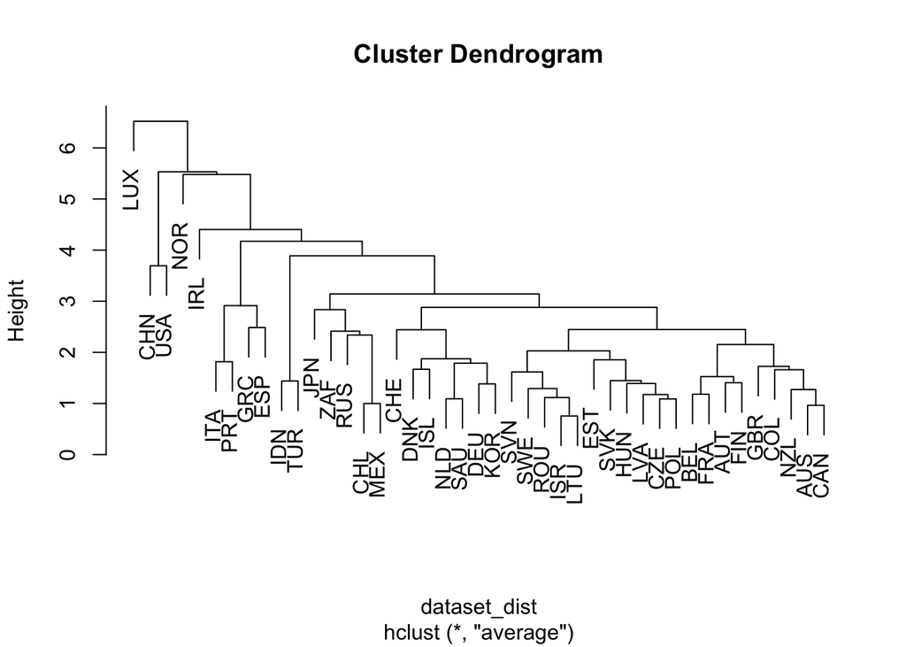

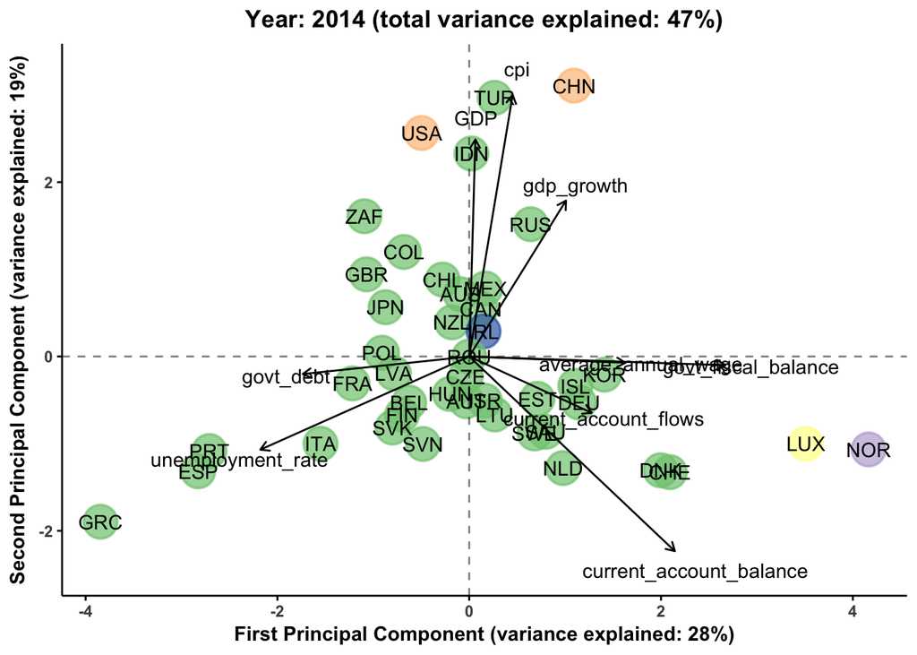

For this reason, we redo this analysis keeping only some of the more stable variables, also for 2014 and with 5 clusters. This gives us a completely different picture, with Greece and Spain a separate high-debt, high-unemployment cluster. Many emerging economies appear clustered together due to their high inflation rate. Again, China and the USA are clustered together probably due to the large size of their GDP. Luxembourg and Norway are clustered together in a ‘high productivity’ cluster. Note that now the first two principal components explain 60% of the variance in the dataset and seems to provide a more coherent picture.

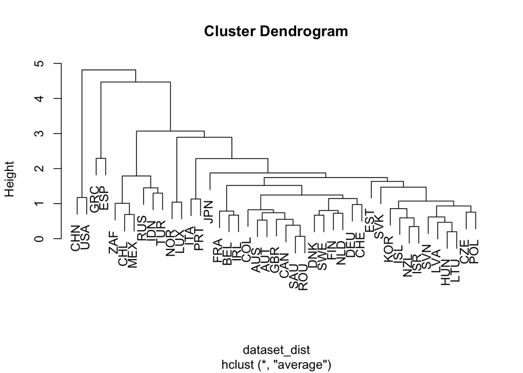

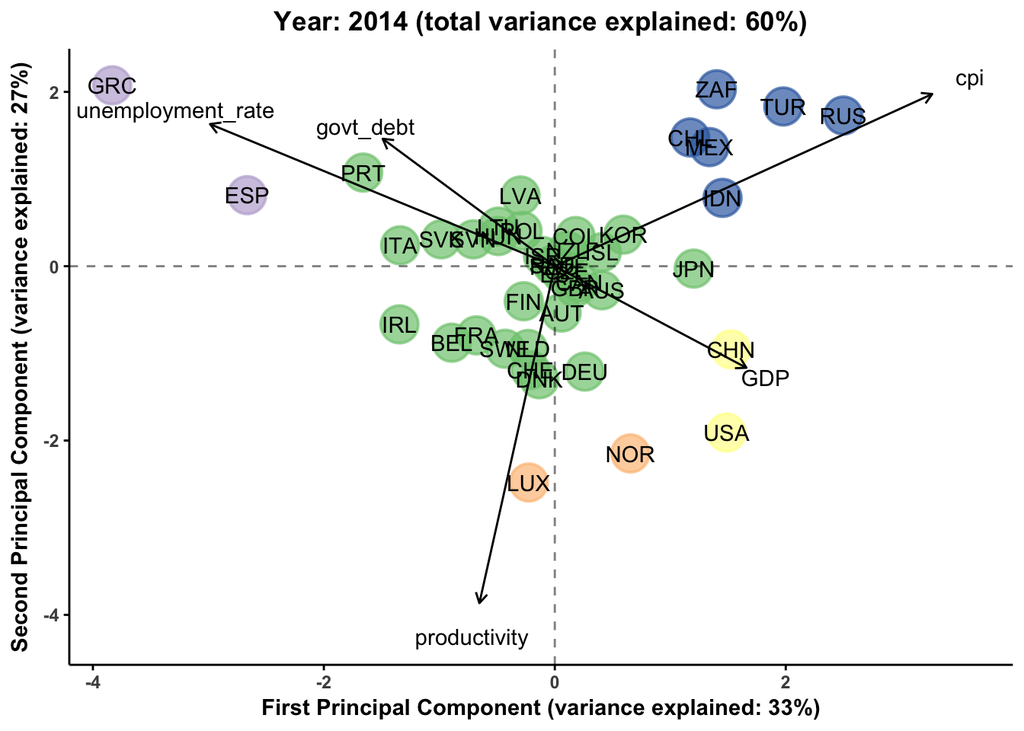

If we increase the number of clusters to 8, we see that Greece and Spain split into separate clusters, while Portugal and Italy get put into a cluster of their own. The extra clusters do not seem to fundamentally change the picture, apart from another separate cluster for Japan.

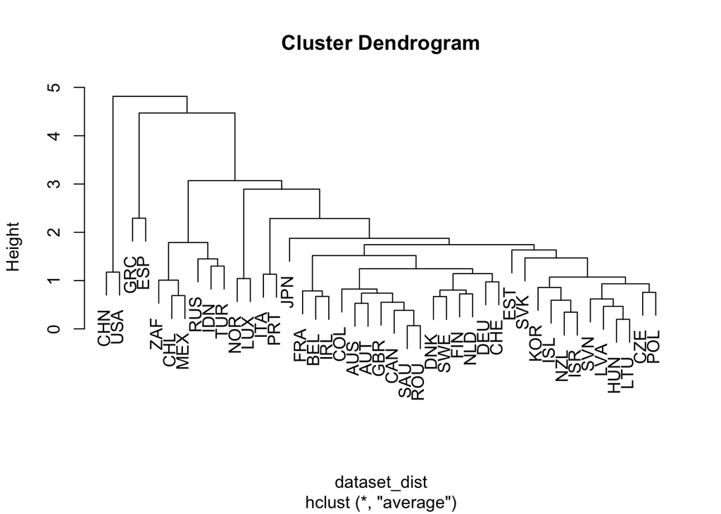

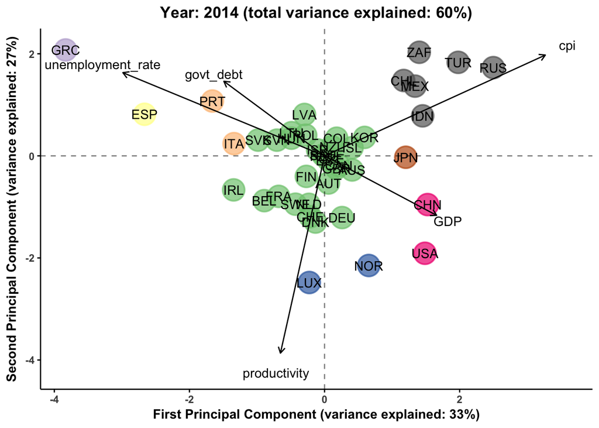

We can change the variables we select to get a different picture, by keeping only inflation, current account balance, productivity, Gross Expenditure on Research and Development (GERD) and investment flows.

Here, beside the central cluster of countries, we notice two groups emerging in particular: high-inflation countries, split into two clusters. These countries also invest relatively little in R&D, have low productivity, and a negative current account balance in 2014. On the side, we find a cluster of countries with higher-than-average current account balances, high productivity and high R&D investment: these include Germany, Switzerland, the Netherlands, Sweden, Denmark, and Saudi Arabia (which is odd).

Other notable patterns include the creation of a Luxembourg cluster due to its high level of openness (high investment flows relative to GDP). We also find Israel and South Korea in a separate cluster of high investors in Research and Development.

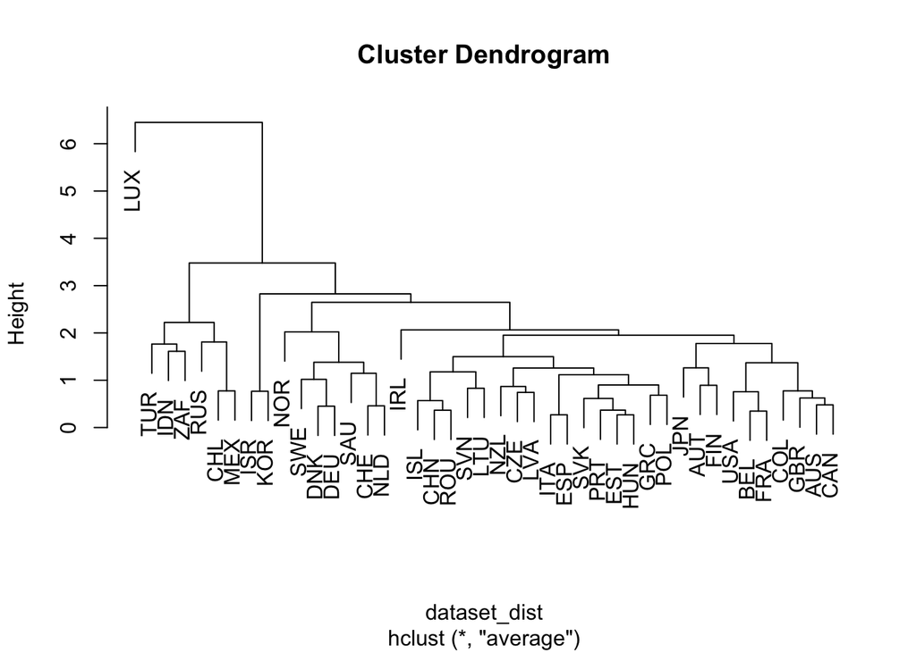

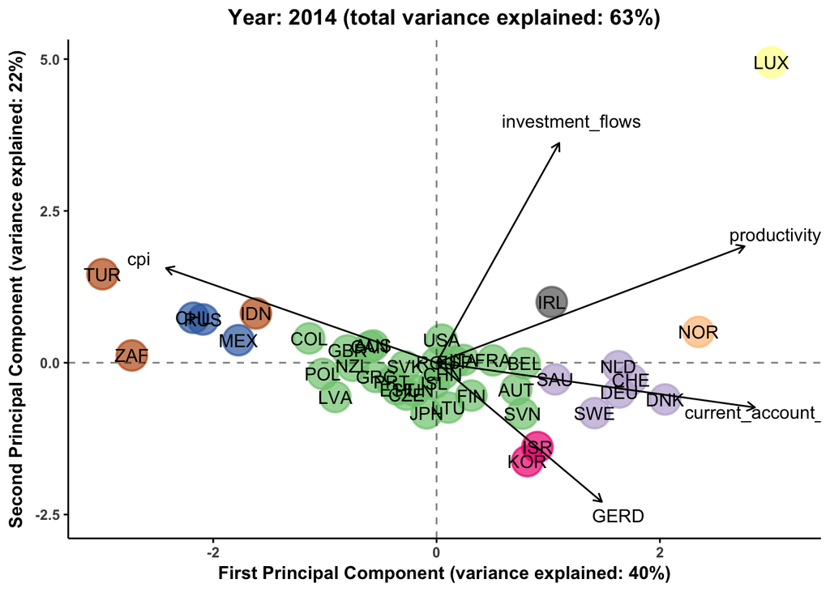

If we turn the clock back to 2008, the year the financial crisis start to hit Europe severely, we can see that the biggest difference with the previous plots is the creation of a cluster which includes Baltic countries alongside emerging economies such as Russia, South Africa and Chile. They mostly seem to be influenced by the ‘cpi’ axis, which may be due to the significant depreciations which ocurred in these countries following the bursting of a housing bubble. Italy, France and Germany are in a cluster, oddly enough with Greece (which, it is true, had not yet felt the heat of the crisis).

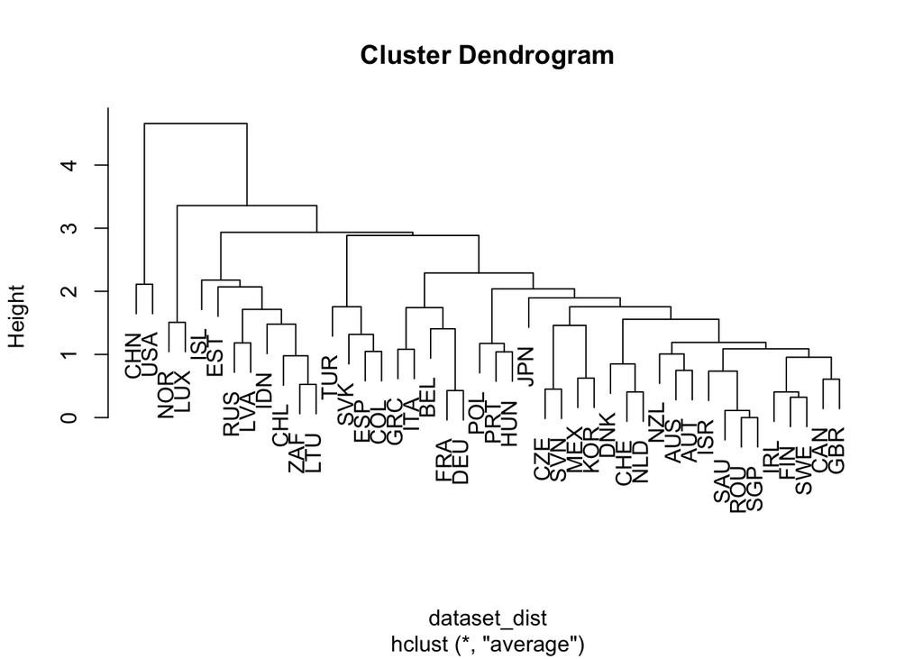

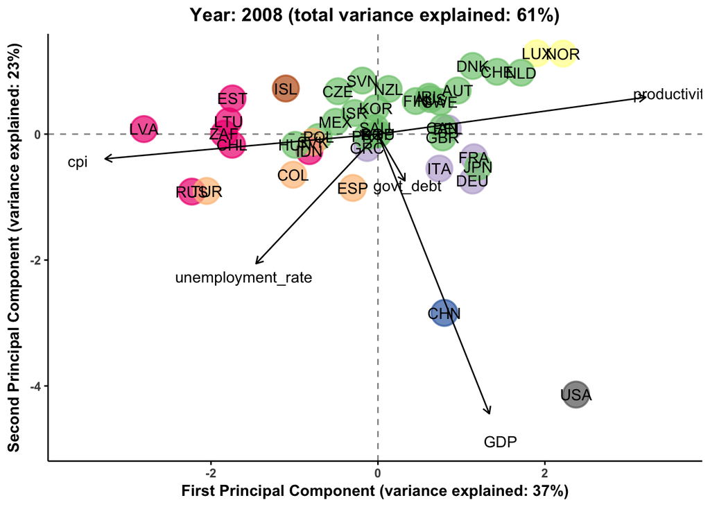

Finally, turning the clock back to 1995, we can see most countries are squeezed together by the sheer size of the US economy (along the ‘gdp’ axis), and the high inflation rate in Russia.

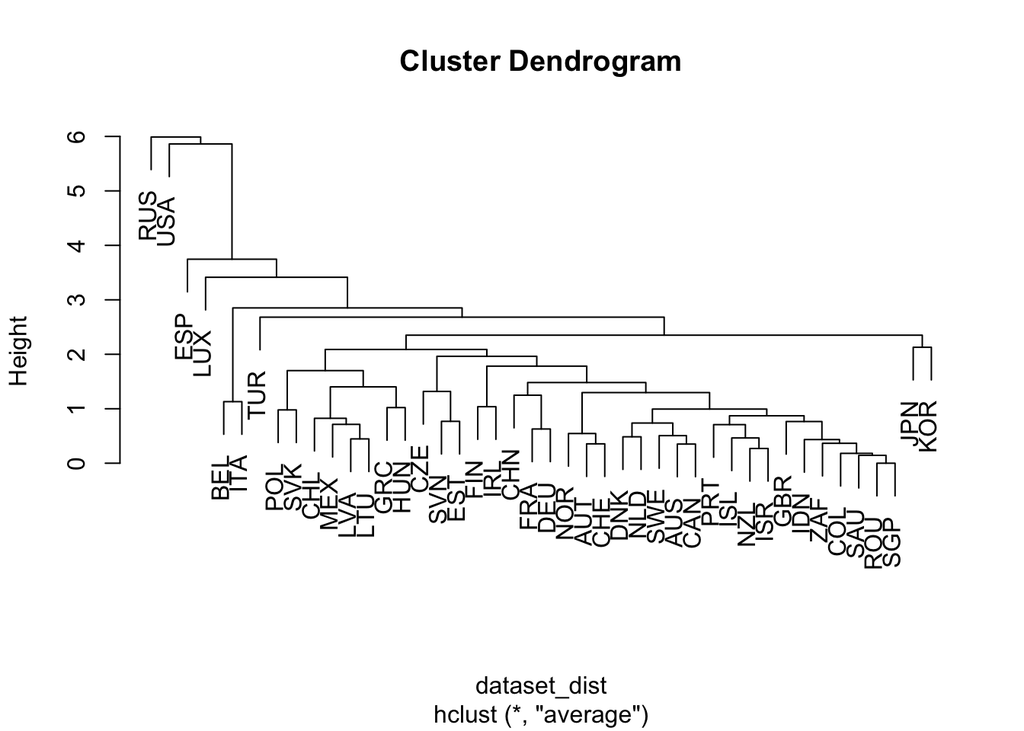

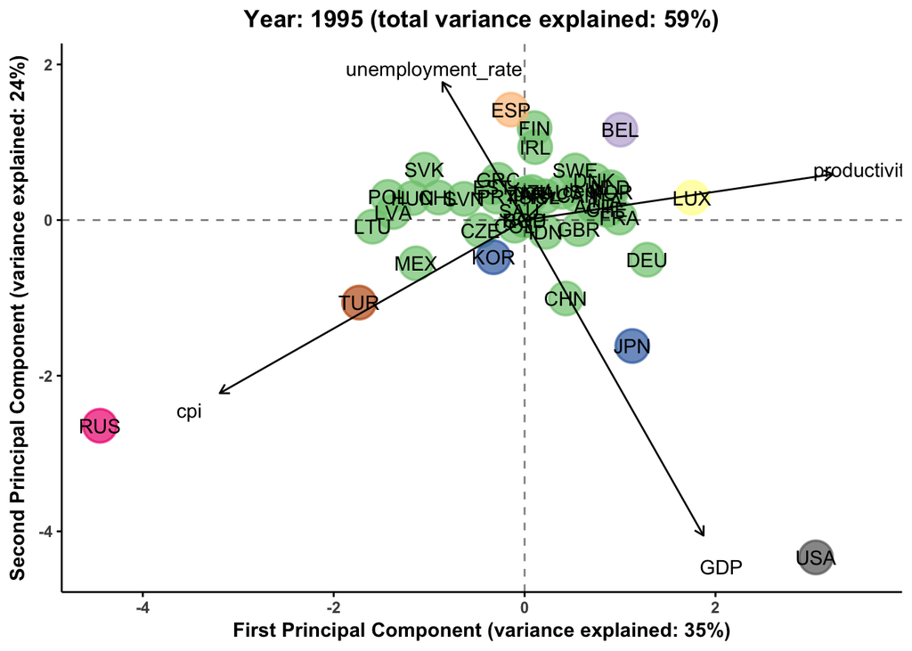

### Conclusion

- Using biplots and dendrograms can reveal interesting patterns in variance and proximity between countries, using macroeconomic variables - although they sometimes provide unexpected results.
- The clustering exercises suggest EU countries are close to each other, perhaps with the exception of Luxembourg (due to its openness, wealth and small size), and Greece and Spain (due to their high unemployment and public debt).
- Despite its strive for leaving the European Union, the UK seems economically very well suited to coordinating its economic policies with other EU countries.
- Overall, this clustering exercise can help us detect patterns in macroeconomic data across countries, and may help in formulating strategies for macroeconomic policy coordination.